# Time Series Models with Python

##### Author: Konstantinos Paganopoulos

We first load the necessary libraries.

```python
import numpy as np
import pandas as pd
from math import sqrt
import seaborn as sns
import statsmodels.api as sm
import matplotlib.pyplot as plt
from matplotlib import rcParams
from pmdarima.arima import auto_arima
from statsmodels.tsa.seasonal import STL
from statsmodels.tsa.stattools import adfuller
from sklearn.metrics import mean_squared_error
from statsmodels.graphics.tsaplots import plot_acf
from statsmodels.graphics.tsaplots import plot_pacf
from statsmodels.tsa.seasonal import seasonal_decompose
from statsmodels.tsa.holtwinters import ExponentialSmoothing
```

We then load the data and inspect them.

```python
df = pd.read_csv('data.csv')
```

```python
df.head()
```

|  | year | month | mean_temp | mean_max_temp | mean_min_temp | max_temp | min_temp | precipitation | highest_daily_prec | mean_wind_speed | highest_wind_gust | dom_wind_direction | mean_rel_humidity | mean_atm_pressure |
| --- | --- | --- | --- | --- | --- | --- | --- | --- | --- | --- | --- | --- | --- | --- |
| 0 | 2001 | 1 | -2.7 | 0.0 | -5.3 | 7.4 | -10.5 | 186.0 | 17.5 | 16.2 | 83.5 | SW | 79 | 1013.5 |
| 1 | 2001 | 2 | -2.5 | 0.2 | -5.0 | 8.3 | -9.9 | 122.5 | 13.5 | 17.2 | 114.1 | WNW | 75 | 1016.6 |
| 2 | 2001 | 3 | 2.1 | 5.6 | -1.3 | 13.7 | -7.7 | 66.5 | 11.0 | 15.5 | 97.2 | SW | 68 | 1008.9 |
| 3 | 2001 | 4 | 9.1 | 14.6 | 4.2 | 22.9 | -0.3 | 31.5 | 15.0 | 15.5 | 107.6 | SW | 60 | 1013.2 |
| 4 | 2001 | 5 | 13.7 | 18.4 | 9.2 | 29.1 | 3.0 | 81.5 | 24.5 | 13.3 | 79.9 | SW | 70 | 1010.6 |

We group mean temperature data by month and calculate the average for our data to see how mean temperature flactuates over months.

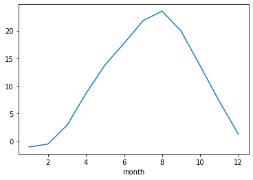

```python
df.groupby('month').mean_temp.mean().plot()
plt.show()
```

We can see that winter months are cold with an average temperature below 0 degrees celcius during January, and summers mild reaching an average temperature below 25 degrees celsius during August.

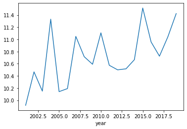

```python
df.groupby('year').mean_temp.mean().plot()
plt.show()
```

We will now inspect the data types.

```python
df.dtypes
```

```
year                    int64
month                   int64
mean_temp             float64
mean_max_temp         float64
mean_min_temp         float64
max_temp              float64
min_temp              float64
precipitation         float64
highest_daily_prec    float64
mean_wind_speed       float64
highest_wind_gust     float64
dom_wind_direction     object
mean_rel_humidity       int64
mean_atm_pressure     float64
dtype: object
```

We will combine month and year column to one column, called date and convert to datetime type. We also drop the previous year and month columns.

```python
df["date"] = pd.to_datetime(df["year"].apply(str)  + "/" + df["month"].apply(str))
df = df.drop(['year','month'], axis=1)
df.head(32)
```

|  | mean_temp | mean_max_temp | mean_min_temp | max_temp | min_temp | precipitation | highest_daily_prec | mean_wind_speed | highest_wind_gust | dom_wind_direction | mean_rel_humidity | mean_atm_pressure | date |
| --- | --- | --- | --- | --- | --- | --- | --- | --- | --- | --- | --- | --- | --- |
| 0 | -2.7 | 0.0 | -5.3 | 7.4 | -10.5 | 186.0 | 17.5 | 16.2 | 83.5 | SW | 79 | 1013.5 | 2001-01-01 |
| 1 | -2.5 | 0.2 | -5.0 | 8.3 | -9.9 | 122.5 | 13.5 | 17.2 | 114.1 | WNW | 75 | 1016.6 | 2001-02-01 |
| 2 | 2.1 | 5.6 | -1.3 | 13.7 | -7.7 | 66.5 | 11.0 | 15.5 | 97.2 | SW | 68 | 1008.9 | 2001-03-01 |
| 3 | 9.1 | 14.6 | 4.2 | 22.9 | -0.3 | 31.5 | 15.0 | 15.5 | 107.6 | SW | 60 | 1013.2 | 2001-04-01 |
| 4 | 13.7 | 18.4 | 9.2 | 29.1 | 3.0 | 81.5 | 24.5 | 13.3 | 79.9 | SW | 70 | 1010.6 | 2001-05-01 |
| 5 | 17.2 | 21.3 | 13.9 | 28.7 | 9.8 | 67.5 | 15.0 | 14.0 | 81.0 | W | 74 | 1007.5 | 2001-06-01 |
| 6 | 21.9 | 26.1 | 18.9 | 31.3 | 15.7 | 216.0 | 43.0 | 11.5 | 77.7 | E | 80 | 1008.2 | 2001-07-01 |
| 7 | 21.4 | 25.8 | 18.1 | 30.1 | 10.7 | 70.5 | 24.0 | 11.1 | 59.7 | E | 79 | 1010.3 | 2001-08-01 |
| 8 | 18.7 | 23.1 | 14.5 | 27.6 | 5.9 | 176.5 | 74.0 | 11.1 | 63.4 | SSW | 74 | 1013.6 | 2001-09-01 |
| 9 | 13.6 | 17.9 | 9.6 | 22.5 | 3.9 | 103.0 | 26.0 | 12.6 | 84.2 | SW | 72 | 1016.9 | 2001-10-01 |
| 10 | 7.3 | 11.5 | 3.4 | 18.9 | -1.8 | 129.5 | 22.5 | 14.7 | 68.7 | SW | 68 | 1015.1 | 2001-11-01 |
| 11 | -0.8 | 1.4 | -3.0 | 6.0 | -5.0 | 149.5 | 19.5 | 15.9 | 94.0 | SW | 76 | 1017.3 | 2001-12-01 |
| 12 | -0.2 | 2.4 | -2.6 | 9.2 | -6.8 | 177.5 | 36.5 | 13.7 | 76.3 | SW | 77 | 1011.1 | 2002-01-01 |
| 13 | 0.6 | 4.1 | -2.7 | 8.7 | -7.8 | 52.5 | 9.0 | 14.0 | 84.2 | SW | 73 | 1015.9 | 2002-02-01 |
| 14 | 4.4 | 8.5 | 0.3 | 20.1 | -5.4 | 88.5 | 14.0 | 16.6 | 101.5 | SW | 64 | 1011.6 | 2002-03-01 |
| 15 | 10.7 | 16.3 | 5.9 | 25.1 | 0.0 | 38.5 | 13.5 | 12.6 | 81.0 | SSW | 63 | 1014.9 | 2002-04-01 |
| 16 | 13.6 | 18.6 | 9.3 | 27.7 | 5.1 | 55.0 | 12.0 | 13.5 | 66.2 | SW | 66 | 1012.2 | 2002-05-01 |
| 17 | 16.9 | 21.7 | 13.2 | 31.2 | 8.3 | 103.0 | 35.0 | 13.0 | 67.7 | E | 73 | 1008.6 | 2002-06-01 |
| 18 | 21.5 | 25.2 | 18.7 | 31.9 | 14.6 | 145.5 | 37.0 | 10.8 | 63.7 | N | 81 | 1007.3 | 2002-07-01 |
| 19 | 21.9 | 25.6 | 19.0 | 31.6 | 13.3 | 316.5 | 94.0 | 11.1 | 68.8 | SW | 81 | 1009.0 | 2002-08-01 |
| 20 | 19.0 | 23.5 | 15.1 | 33.6 | 8.7 | 113.5 | 50.0 | 10.8 | 59.8 | SSW | 74 | 1014.0 | 2002-09-01 |
| 21 | 13.4 | 18.0 | 9.2 | 26.9 | 3.5 | 107.0 | 18.5 | 13.7 | 110.5 | SW | 71 | 1013.7 | 2002-10-01 |
| 22 | 4.1 | 7.6 | 0.7 | 14.2 | -3.1 | 185.0 | 35.5 | 15.5 | 84.2 | SW | 73 | 1013.1 | 2002-11-01 |
| 23 | -0.3 | 2.5 | -2.8 | 11.0 | -8.9 | 143.0 | 34.5 | 14.8 | 79.2 | WSW | 72 | 1018.9 | 2002-12-01 |
| 24 | -1.2 | 1.5 | -4.0 | 7.9 | -8.6 | 123.5 | 16.0 | 15.8 | 88.9 | WSW | 75 | 1012.4 | 2003-01-01 |
| 25 | -0.6 | 2.3 | -3.5 | 7.3 | -8.4 | 65.5 | 11.5 | 13.0 | 67.3 | SW | 74 | 1017.6 | 2003-02-01 |
| 26 | 2.3 | 6.2 | -1.3 | 14.5 | -6.3 | 101.5 | 21.5 | 15.1 | 97.9 | SW | 67 | 1015.7 | 2003-03-01 |
| 27 | 9.3 | 14.5 | 4.6 | 25.5 | -0.5 | 97.5 | 23.5 | 14.0 | 97.2 | SW | 66 | 1013.2 | 2003-04-01 |
| 28 | 13.4 | 18.2 | 9.3 | 26.9 | 3.2 | 56.5 | 32.0 | 11.1 | 75.2 | N | 72 | 1014.8 | 2003-05-01 |
| 29 | 17.3 | 21.7 | 14.0 | 29.5 | 7.6 | 117.0 | 37.5 | 12.2 | 71.9 | N | 77 | 1007.8 | 2003-06-01 |
| 30 | 18.1 | 22.1 | 15.3 | 27.3 | 12.1 | 71.5 | 25.0 | 13.3 | 59.8 | E | 79 | 1010.2 | 2003-07-01 |
| 31 | 21.3 | 25.2 | 18.4 | 31.5 | 14.8 | 167.0 | 51.5 | 11.5 | 64.8 | E | 81 | 1009.8 | 2003-08-01 |

We now check that type of date column is converted to datetime.

```python
df.dtypes
```

```
mean_temp                    float64
mean_max_temp                float64
mean_min_temp                float64
max_temp                     float64
min_temp                     float64
precipitation                float64
highest_daily_prec           float64
mean_wind_speed              float64
highest_wind_gust            float64
dom_wind_direction            object
mean_rel_humidity              int64
mean_atm_pressure            float64
date                  datetime64[ns]
dtype: object
```

We then set the index to date column so as to transform to timeseries data.

```python
#Ensure the date data is in datetime format
df["date"] = pd.to_datetime(df["date"], format = '%Y-%m-%d')

#Set the date to the index
df.set_index("date", inplace = True)
```

```python
df.head(13) #Take a peek at the data
```

| date | mean_temp | mean_max_temp | mean_min_temp | max_temp | min_temp | precipitation | highest_daily_prec | mean_wind_speed | highest_wind_gust | dom_wind_direction | mean_rel_humidity | mean_atm_pressure |
| --- | --- | --- | --- | --- | --- | --- | --- | --- | --- | --- | --- | --- |
| 2001-01-01 | -2.7 | 0.0 | -5.3 | 7.4 | -10.5 | 186.0 | 17.5 | 16.2 | 83.5 | SW | 79 | 1013.5 |
| 2001-02-01 | -2.5 | 0.2 | -5.0 | 8.3 | -9.9 | 122.5 | 13.5 | 17.2 | 114.1 | WNW | 75 | 1016.6 |
| 2001-03-01 | 2.1 | 5.6 | -1.3 | 13.7 | -7.7 | 66.5 | 11.0 | 15.5 | 97.2 | SW | 68 | 1008.9 |
| 2001-04-01 | 9.1 | 14.6 | 4.2 | 22.9 | -0.3 | 31.5 | 15.0 | 15.5 | 107.6 | SW | 60 | 1013.2 |
| 2001-05-01 | 13.7 | 18.4 | 9.2 | 29.1 | 3.0 | 81.5 | 24.5 | 13.3 | 79.9 | SW | 70 | 1010.6 |
| 2001-06-01 | 17.2 | 21.3 | 13.9 | 28.7 | 9.8 | 67.5 | 15.0 | 14.0 | 81.0 | W | 74 | 1007.5 |
| 2001-07-01 | 21.9 | 26.1 | 18.9 | 31.3 | 15.7 | 216.0 | 43.0 | 11.5 | 77.7 | E | 80 | 1008.2 |
| 2001-08-01 | 21.4 | 25.8 | 18.1 | 30.1 | 10.7 | 70.5 | 24.0 | 11.1 | 59.7 | E | 79 | 1010.3 |
| 2001-09-01 | 18.7 | 23.1 | 14.5 | 27.6 | 5.9 | 176.5 | 74.0 | 11.1 | 63.4 | SSW | 74 | 1013.6 |
| 2001-10-01 | 13.6 | 17.9 | 9.6 | 22.5 | 3.9 | 103.0 | 26.0 | 12.6 | 84.2 | SW | 72 | 1016.9 |
| 2001-11-01 | 7.3 | 11.5 | 3.4 | 18.9 | -1.8 | 129.5 | 22.5 | 14.7 | 68.7 | SW | 68 | 1015.1 |
| 2001-12-01 | -0.8 | 1.4 | -3.0 | 6.0 | -5.0 | 149.5 | 19.5 | 15.9 | 94.0 | SW | 76 | 1017.3 |
| 2002-01-01 | -0.2 | 2.4 | -2.6 | 9.2 | -6.8 | 177.5 | 36.5 | 13.7 | 76.3 | SW | 77 | 1011.1 |

We check for null values.

```python
df.isnull().any()
```

```
mean_temp             False
mean_max_temp         False
mean_min_temp         False
max_temp              False
min_temp              False
precipitation         False
highest_daily_prec    False
mean_wind_speed       False
highest_wind_gust     False
dom_wind_direction    False
mean_rel_humidity     False
mean_atm_pressure     False
dtype: bool
```

And we visually inspect our data.

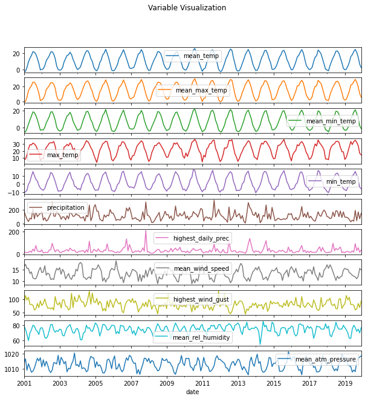

```python
plt.rcParams['figure.figsize'] = (10,10) #Set the figure size
df.plot(subplots = True, title = "Variable Visualization") #Plot all the variables
plt.show()
```

##### ARIMA

We first split our data set to train and validation set.

```python
df_train = df[:204]
df_val = df[204:216]
df_val
# we leave one month data for our test set
```

| date | mean_temp | mean_max_temp | mean_min_temp | max_temp | min_temp | precipitation | highest_daily_prec | mean_wind_speed | highest_wind_gust | dom_wind_direction | mean_rel_humidity | mean_atm_pressure |
| --- | --- | --- | --- | --- | --- | --- | --- | --- | --- | --- | --- | --- |
| 2018-01-01 | -0.9 | 2.0 | -3.4 | 8.3 | -9.5 | 104.0 | 9.0 | 17.0 | 97.2 | SW | 76 | 1012.2 |
| 2018-02-01 | -1.9 | 1.4 | -5.1 | 7.3 | -10.7 | 97.5 | 15.0 | 15.5 | 95.8 | SW | 79 | 1015.5 |
| 2018-03-01 | 4.6 | 9.1 | -0.1 | 21.4 | -5.8 | 74.5 | 14.0 | 17.0 | 104.0 | SSW | 67 | 1016.4 |
| 2018-04-01 | 9.6 | 14.6 | 5.5 | 26.7 | 0.7 | 82.5 | 22.0 | 15.8 | 80.6 | SSW | 65 | 1013.3 |
| 2018-05-01 | 14.2 | 19.3 | 9.7 | 29.1 | 4.1 | 169.5 | 94.0 | 14.0 | 76.3 | SW | 71 | 1010.5 |
| 2018-06-01 | 17.8 | 22.8 | 14.0 | 30.4 | 10.0 | 102.0 | 28.0 | 12.2 | 82.4 | SW | 75 | 1008.5 |
| 2018-07-01 | 22.6 | 26.7 | 19.6 | 33.6 | 13.0 | 191.0 | 49.5 | 10.4 | 64.8 | NW | 84 | 1009.8 |
| 2018-08-01 | 22.8 | 27.4 | 19.3 | 34.0 | 13.8 | 180.5 | 37.0 | 12.2 | 64.1 | ENE | 78 | 1008.5 |
| 2018-09-01 | 20.0 | 24.7 | 16.1 | 32.7 | 10.4 | 103.0 | 47.5 | 11.2 | 100.4 | SSW | 75 | 1013.4 |
| 2018-10-01 | 14.2 | 19.3 | 10.1 | 25.1 | 5.4 | 185.5 | 61.0 | 11.9 | 102.6 | SSW | 75 | 1015.2 |
| 2018-11-01 | 8.3 | 12.4 | 4.6 | 18.9 | -2.2 | 90.5 | 11.5 | 12.2 | 65.5 | SSW | 75 | 1019.8 |
| 2018-12-01 | 1.2 | 4.2 | -1.2 | 18.6 | -5.9 | 172.5 | 18.5 | 14.8 | 75.6 | SW | 80 | 1017.5 |

We choose the mean temperature column, as we want to predict the mean temperature for the next year.

```python
mean_temp_train = df_train[['mean_temp']]
mean_temp_val = df_val[['mean_temp']]
mean_temp_train.head(13)
```

| date | mean_temp |
| --- | --- |
| 2001-01-01 | -2.7 |
| 2001-02-01 | -2.5 |
| 2001-03-01 | 2.1 |
| 2001-04-01 | 9.1 |
| 2001-05-01 | 13.7 |
| 2001-06-01 | 17.2 |
| 2001-07-01 | 21.9 |
| 2001-08-01 | 21.4 |
| 2001-09-01 | 18.7 |
| 2001-10-01 | 13.6 |
| 2001-11-01 | 7.3 |
| 2001-12-01 | -0.8 |
| 2002-01-01 | -0.2 |

We visually inspect the time series.

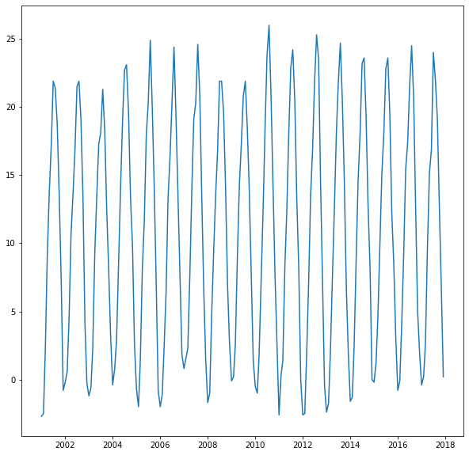

```python
plt.plot(mean_temp_train['mean_temp'])
plt.show()
```

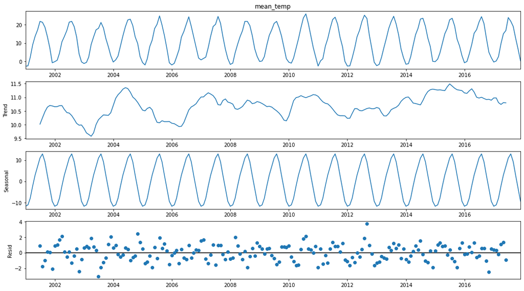

```python
decomposition = seasonal_decompose(mean_temp_train['mean_temp'], freq=12)
fig = plt.figure()
fig = decomposition.plot()
fig.set_size_inches(15, 8)
plt.show()
```

In a stationary time series, statistical properties such as mean and variance are constant over time. In a non-stationary series, these properties are dependent on time.

From the above graphs we can see that mean and variance stay quite constant over time. We can check if the data are stationary by performing an ADFuller test.

```python
# stationary test
# adf stationarity test
print("ADFuller Test; Significance: 0.05") #Print the significance level

#Do the ADFuller test for each column
adf = adfuller(mean_temp_train['mean_temp']) #Call adfuller to test
print("The Test Statistic for mean temperature is {}".format(round(adf[0],1)))
print("The p-value for mean temperature is {}".format(round(adf[1],2))) #Print the adfuller results
```

```
ADFuller Test; Significance: 0.05
The Test Statistic for mean temperature is -3.2
The p-value for mean temperature is 0.02
```

Hence since $P-Value < 0.05$ (Significance Level defined), we reject the Null Hypothesis that the time series contains a unit root. In other words, by rejecting the Null hypothesis, we can conclude that the time series is stationary.

We now plot the acf and pacf plots, to see the optimal orders of MA and AR components, even though auto arima function will automatically determine them.

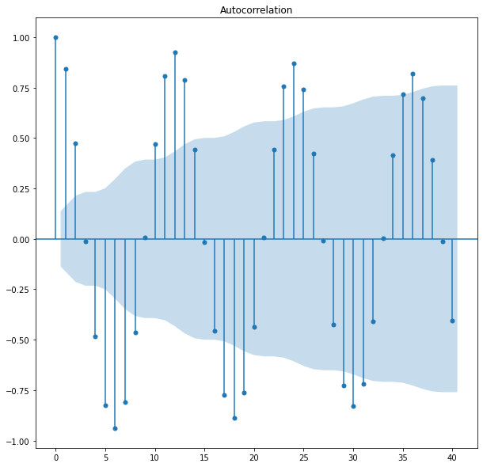

```python
plot_acf(mean_temp_train,lags=40)
plt.show()
```

Running the example creates a 2D plot showing the lag value along the x-axis and the correlation on the y-axis between -1 and 1.

Confidence intervals are drawn as a cone. By default, this is set to a 95% confidence interval, suggesting that correlation values outside of this code are very likely a correlation and not a statistical fluke.

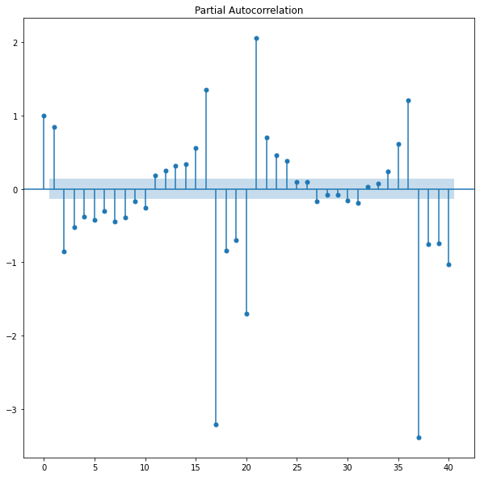

```python
plot_pacf(mean_temp_train, lags=40)
plt.show()
```

The graph above calculates and plots a partial autocorrelation function for the first 40 lags in the Mean Monthly Temperatures dataset using the plot_pacf() from the statsmodels library.

Next we use auto arima function to search for the best ARIMA models.

```python
#building and fiting the model
arima_model = auto_arima(mean_temp_train, trace = True, error_action = 'ignore', suppress_warnings = True)
arima_model.summary()
```

```
Performing stepwise search to minimize aic
 ARIMA(2,0,2)(0,0,0)[0] intercept   : AIC=730.036, Time=0.33 sec
 ARIMA(0,0,0)(0,0,0)[0] intercept   : AIC=1460.742, Time=0.01 sec
 ARIMA(1,0,0)(0,0,0)[0] intercept   : AIC=1200.637, Time=0.03 sec
 ARIMA(0,0,1)(0,0,0)[0] intercept   : AIC=1247.910, Time=0.04 sec
 ARIMA(0,0,0)(0,0,0)[0]             : AIC=1648.551, Time=0.01 sec
 ARIMA(1,0,2)(0,0,0)[0] intercept   : AIC=1027.572, Time=0.08 sec
 ARIMA(2,0,1)(0,0,0)[0] intercept   : AIC=771.601, Time=0.18 sec
 ARIMA(3,0,2)(0,0,0)[0] intercept   : AIC=774.861, Time=0.36 sec
 ARIMA(2,0,3)(0,0,0)[0] intercept   : AIC=712.293, Time=0.35 sec
 ARIMA(1,0,3)(0,0,0)[0] intercept   : AIC=1001.329, Time=0.11 sec
 ARIMA(3,0,3)(0,0,0)[0] intercept   : AIC=inf, Time=0.38 sec
 ARIMA(2,0,4)(0,0,0)[0] intercept   : AIC=711.106, Time=0.38 sec
 ARIMA(1,0,4)(0,0,0)[0] intercept   : AIC=969.360, Time=0.22 sec
 ARIMA(3,0,4)(0,0,0)[0] intercept   : AIC=inf, Time=0.44 sec
 ARIMA(2,0,5)(0,0,0)[0] intercept   : AIC=inf, Time=0.42 sec
 ARIMA(1,0,5)(0,0,0)[0] intercept   : AIC=inf, Time=0.42 sec
 ARIMA(3,0,5)(0,0,0)[0] intercept   : AIC=inf, Time=0.49 sec
 ARIMA(2,0,4)(0,0,0)[0]             : AIC=973.398, Time=0.16 sec

Best model:  ARIMA(2,0,4)(0,0,0)[0] intercept
Total fit time: 4.447 seconds
```

SARIMAX Results

| Dep. Variable: | y | No. Observations: | 204 |
| --- | --- | --- | --- |
| Model: | SARIMAX(2, 0, 4) | Log Likelihood | -347.553 |
| Date: | Fri, 30 Jul 2021 | AIC | 711.106 |
| Time: | 16:53:23 | BIC | 737.651 |
| Sample: | 0 | HQIC | 721.844 |
|  | - 204 |  |  |
| Covariance Type: | opg |  |  |

|  | coef | std err | z | P>\|z\| | [0.025 | 0.975] |
| --- | --- | --- | --- | --- | --- | --- |
| intercept | 2.8586 | 0.036 | 80.043 | 0.000 | 2.789 | 2.929 |
| ar.L1 | 1.7320 | 0.000 | 3496.203 | 0.000 | 1.731 | 1.733 |
| ar.L2 | -1.0000 | 8.46e-05 | -1.18e+04 | 0.000 | -1.000 | -1.000 |
| ma.L1 | -1.2931 | 0.070 | -18.523 | 0.000 | -1.430 | -1.156 |
| ma.L2 | 0.3502 | 0.119 | 2.953 | 0.003 | 0.118 | 0.583 |
| ma.L3 | 0.2110 | 0.125 | 1.692 | 0.091 | -0.033 | 0.455 |
| ma.L4 | 0.1164 | 0.077 | 1.505 | 0.132 | -0.035 | 0.268 |
| sigma2 | 1.6753 | 0.172 | 9.745 | 0.000 | 1.338 | 2.012 |

| Ljung-Box (L1) (Q): | 0.19 | Jarque-Bera (JB): | 0.64 |
| --- | --- | --- | --- |
| Prob(Q): | 0.66 | Prob(JB): | 0.73 |
| Heteroskedasticity (H): | 0.95 | Skew: | 0.13 |
| Prob(H) (two-sided): | 0.83 | Kurtosis: | 3.11 |

Warnings:  
[1] Covariance matrix calculated using the outer product of gradients (complex-step).

The output above shows that the final model fitted was an ARIMA(2,0,4) estimator, where the values of the parameters p, d, and q were two, zero, and four, respectively. The auto_arima functions tests the time series with different combinations of p, d, and q using AIC as the criterion. AIC stands for Akaike Information Criterion, which estimates the relative amount of information lost by a given model. In simple terms, a lower AIC value is preferred. In the above output, the lowest AIC value of 711.106 was obtained for the ARIMA(2, 0, 4) model, and that is used as the final estimator.

In the post-estimation analysis, we would also like to check out the residual plots, including time series, ACFs and etc, to make sure that there is no warning signal. In particular, residuals shall have a zero mean, constant variance, and distributed symmetrically around mean zero. ACF of any lag greater 0 is expected to be statistically insignificant.

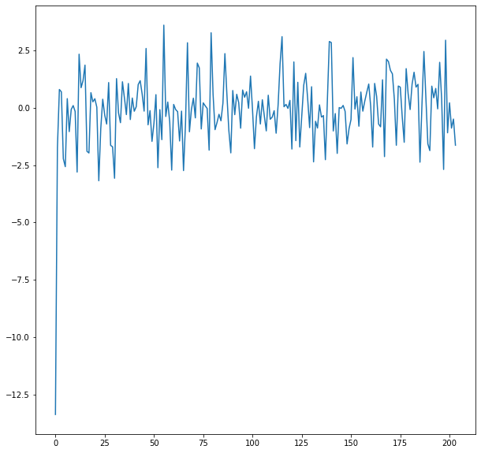

```python
#residuals
residuals = arima_model.resid()
plt.plot(residuals)
plt.show()
```

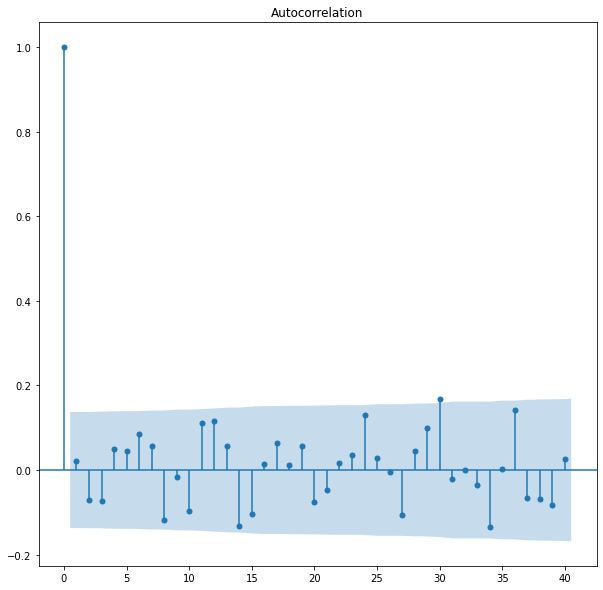

```python
plot_acf(residuals,lags=40)
plt.show()
```

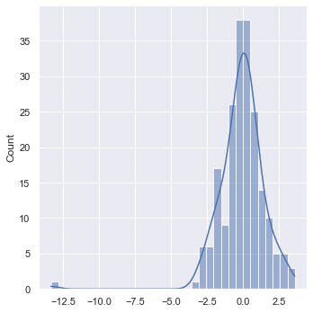

```python
sns.set_theme()
sns.displot(residuals, kde=True)
plt.show()
```

We now predict the monthly mean temperature for the next year.

```python
# prediction for 2018
forecast = arima_model.predict(n_periods=12).round(1)
forecast
```

```
array([-1.6, -0.9,  2.5,  7.9, 14. , 19.3, 22.2, 22.1, 18.9, 13.5,  7.3,
        2.1])
```

Now we evaluate the in-sample performance/fit of the model with mean squared error function, which summarizes various measures of fitting errors. Afterwards we will calculate the square root of the mean squared error, so as to evaluate our model based on the root mean squared error.

```python
#calculate rmse
rms = round(sqrt(mean_squared_error(mean_temp_val,forecast)),2)
print("The Root Mean Squared Error of {} is {}".format("Mean Temperature for 2018", rms))
```

```
The Root Mean Squared Error of Mean Temperature for 2018 is 1.13
```

We will now use the whole dataset to train our model, and test it on the 2019 data.

First, we split the data accordingly.

```python
df_train = df[:216]
df_test = df[216:]

mean_temp = df_train[['mean_temp']]
mean_temp_test = df_test[['mean_temp']]
```

```python
#building and fiting the model
arima_model_final = auto_arima(mean_temp, trace = True, error_action = 'ignore', suppress_warnings = True)
arima_model_final.summary()
```

```
Performing stepwise search to minimize aic
 ARIMA(2,0,2)(0,0,0)[0] intercept   : AIC=769.188, Time=0.33 sec
 ARIMA(0,0,0)(0,0,0)[0] intercept   : AIC=1546.303, Time=0.01 sec
 ARIMA(1,0,0)(0,0,0)[0] intercept   : AIC=1270.295, Time=0.03 sec
 ARIMA(0,0,1)(0,0,0)[0] intercept   : AIC=1325.458, Time=0.05 sec
 ARIMA(0,0,0)(0,0,0)[0]             : AIC=1745.884, Time=0.01 sec
 ARIMA(1,0,2)(0,0,0)[0] intercept   : AIC=1086.770, Time=0.09 sec
 ARIMA(2,0,1)(0,0,0)[0] intercept   : AIC=814.077, Time=0.23 sec
 ARIMA(3,0,2)(0,0,0)[0] intercept   : AIC=817.137, Time=0.37 sec
 ARIMA(2,0,3)(0,0,0)[0] intercept   : AIC=753.658, Time=0.39 sec
 ARIMA(1,0,3)(0,0,0)[0] intercept   : AIC=1059.740, Time=0.12 sec
 ARIMA(3,0,3)(0,0,0)[0] intercept   : AIC=inf, Time=0.39 sec
 ARIMA(2,0,4)(0,0,0)[0] intercept   : AIC=749.643, Time=0.44 sec
 ARIMA(1,0,4)(0,0,0)[0] intercept   : AIC=1023.438, Time=0.20 sec
 ARIMA(3,0,4)(0,0,0)[0] intercept   : AIC=754.814, Time=0.60 sec
 ARIMA(2,0,5)(0,0,0)[0] intercept   : AIC=747.494, Time=0.55 sec
 ARIMA(1,0,5)(0,0,0)[0] intercept   : AIC=inf, Time=0.47 sec
 ARIMA(3,0,5)(0,0,0)[0] intercept   : AIC=inf, Time=0.58 sec
 ARIMA(2,0,5)(0,0,0)[0]             : AIC=1010.876, Time=0.31 sec

Best model:  ARIMA(2,0,5)(0,0,0)[0] intercept
Total fit time: 5.166 seconds
```

SARIMAX Results

| Dep. Variable: | y | No. Observations: | 216 |
| --- | --- | --- | --- |
| Model: | SARIMAX(2, 0, 5) | Log Likelihood | -364.747 |
| Date: | Fri, 30 Jul 2021 | AIC | 747.494 |
| Time: | 16:53:29 | BIC | 777.872 |
| Sample: | 0 | HQIC | 759.767 |
|  | - 216 |  |  |
| Covariance Type: | opg |  |  |

|  | coef | std err | z | P>\|z\| | [0.025 | 0.975] |
| --- | --- | --- | --- | --- | --- | --- |
| intercept | 2.8668 | 0.024 | 117.106 | 0.000 | 2.819 | 2.915 |
| ar.L1 | 1.7319 | 0.001 | 3146.900 | 0.000 | 1.731 | 1.733 |
| ar.L2 | -0.9998 | 0.000 | -5033.990 | 0.000 | -1.000 | -0.999 |
| ma.L1 | -1.3466 | 0.068 | -19.835 | 0.000 | -1.480 | -1.213 |
| ma.L2 | 0.3138 | 0.117 | 2.679 | 0.007 | 0.084 | 0.543 |
| ma.L3 | 0.2286 | 0.125 | 1.834 | 0.067 | -0.016 | 0.473 |
| ma.L4 | 0.2443 | 0.122 | 1.998 | 0.046 | 0.005 | 0.484 |
| ma.L5 | -0.1571 | 0.073 | -2.141 | 0.032 | -0.301 | -0.013 |
| sigma2 | 1.5755 | 0.149 | 10.607 | 0.000 | 1.284 | 1.867 |

| Ljung-Box (L1) (Q): | 0.01 | Jarque-Bera (JB): | 0.10 |
| --- | --- | --- | --- |
| Prob(Q): | 0.91 | Prob(JB): | 0.95 |
| Heteroskedasticity (H): | 0.75 | Skew: | 0.03 |
| Prob(H) (two-sided): | 0.22 | Kurtosis: | 3.08 |

Warnings:  
[1] Covariance matrix calculated using the outer product of gradients (complex-step).

The output above shows that the final model fitted was an ARIMA(2,0,5) estimator, where the values of the parameters p, d, and q were two, zero, and five, respectively. The auto_arima functions tests the time series with different combinations of p, d, and q using AIC as the criterion. AIC stands for Akaike Information Criterion, which estimates the relative amount of information lost by a given model. In simple terms, a lower AIC value is preferred. In the above output, the lowest AIC value of 747.494 was obtained for the ARIMA(2, 0, 5) model, and that is used as the final estimator.

We now predict the monthly mean temperature for the next year.

```python
# prediction for 2019
final_forecast = arima_model_final.predict(n_periods=12).round(1)
final_forecast
```

```
array([-1.5, -0.9,  2.7,  8.1, 14.3, 19.5, 22.4, 22.1, 18.8, 13.3,  7.1,
        1.9])
```

We evalueate the model performance on the test set.

```python
#calculate rmse
rms = round(sqrt(mean_squared_error(mean_temp_test,final_forecast)),2)
print("The Root Mean Squared Error of {} is {}".format("Mean Temperature for 2018", rms))
```

```
The Root Mean Squared Error of Mean Temperature for 2018 is 1.42
```

```python
mean_temp_test.insert(1, "arima forecast",final_forecast)
mean_temp_test
```

| date | mean_temp | arima forecast |
| --- | --- | --- |
| 2019-01-01 | -0.6 | -1.5 |
| 2019-02-01 | 0.0 | -0.9 |
| 2019-03-01 | 3.8 | 2.7 |
| 2019-04-01 | 8.5 | 8.1 |
| 2019-05-01 | 15.8 | 14.3 |
| 2019-06-01 | 18.1 | 19.5 |
| 2019-07-01 | 22.1 | 22.4 |
| 2019-08-01 | 24.8 | 22.1 |
| 2019-09-01 | 21.2 | 18.8 |
| 2019-10-01 | 15.1 | 13.3 |
| 2019-11-01 | 6.3 | 7.1 |
| 2019-12-01 | 2.0 | 1.9 |

##### Holt-Winters

Now we will use another model to forecast temperature. Our goal is to pick the model with the most accurate predictions.

We will forecast the average montly temperature demand for the next year using Holt-Winters model.

For time series analysis, the first step is always to visually inspect the time series. In this regard, the STL() function is quite useful. It decomposes the original time series into trend, seasonal factors, and random error terms.

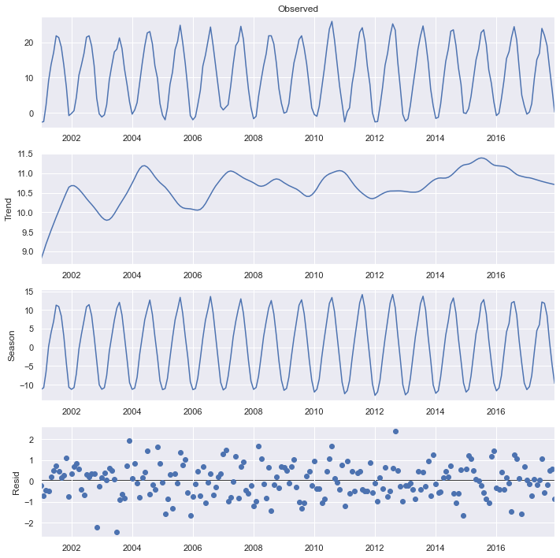

```python
stl = STL(mean_temp_train, seasonal=7)
res = stl.fit()
fig = res.plot()
```

From the above we can conclude that the contribution of the trend component to the variation in the original time series is marginal. Moreover, we can see that there is high seasonality in the data.

Exponential smoothing methods consist of flattening time series data. Exponential smoothing averages or exponentially weighted moving averages consist of forecast based on previous periods data with exponentially declining influence on the older observations.

Exponential smoothing methods consist of special case exponential moving with notation ETS (Error, Trend, Seasonality) where each can be none(N), additive (A), additive damped (Ad), Multiplicative (M) or multiplicative damped (Md).

We use the Holt-Winters - ETS(A, A, A) linear method with additive errors, as this is the appropriate for our case. We build the model and fit it into the train set.

```python
hw = ExponentialSmoothing(np.asarray(mean_temp_train), trend='additive', damped=False, seasonal='additive', seasonal_periods = 12).fit()
hw.summary()
```

ExponentialSmoothing Model Results

| Dep. Variable: | endog | No. Observations: | 204 |
| --- | --- | --- | --- |
| Model: | ExponentialSmoothing | SSE | 263.560 |
| Optimized: | True | AIC | 84.257 |
| Trend: | Additive | BIC | 137.347 |
| Seasonal: | Additive | AICC | 87.954 |
| Seasonal Periods: | 12 | Date: | Fri, 30 Jul 2021 |
| Box-Cox: | False | Time: | 16:53:30 |
| Box-Cox Coeff.: | None |  |  |

|  | coeff | code | optimized |
| --- | --- | --- | --- |
| smoothing_level | 1.4968e-08 | alpha | True |
| smoothing_trend | 2.5711e-10 | beta | True |
| smoothing_seasonal | 6.5179e-11 | gamma | True |
| initial_level | -0.7759036 | l.0 | True |
| initial_trend | 0.0033990 | b.0 | True |
| initial_seasons.0 | -0.6890815 | s.0 | True |
| initial_seasons.1 | -0.0807202 | s.1 | True |
| initial_seasons.2 | 3.1217651 | s.2 | True |
| initial_seasons.3 | 9.0124876 | s.3 | True |
| initial_seasons.4 | 14.079671 | s.4 | True |
| initial_seasons.5 | 18.093909 | s.5 | True |
| initial_seasons.6 | 22.178752 | s.6 | True |
| initial_seasons.7 | 23.910635 | s.7 | True |
| initial_seasons.8 | 20.242542 | s.8 | True |
| initial_seasons.9 | 13.892082 | s.9 | True |
| initial_seasons.10 | 7.6063316 | s.10 | True |
| initial_seasons.11 | 1.6146894 | s.11 | True |

The output above shows that the final model fitted was an ExponentialSmoothing or ETS(A,A,A). The lowest AIC value, that of 84.257 was obtained with the aboce model.

We now predict the monthly mean temperature for the next year.

```python
# prediction for 2018
hw_forecast = hw.forecast(steps = 12).round(1)
hw_forecast
```

```
array([-0.8, -0.2,  3. ,  8.9, 14. , 18. , 22.1, 23.9, 20.2, 13.8,  7.6,
        1.6])
```

Now we evaluate the in-sample performance/fit of the model with mean squared error function, which summarizes various measures of fitting errors. Afterwards we will calculate the square root of the mean squared error, so as to evaluate our model based on the root mean squared error.

```python
#calculate rmse
rms = round(sqrt(mean_squared_error(mean_temp_val,hw_forecast)),2)
print("The Root Mean Squared Error of {} is {}".format("Mean Temperature for 2018", rms))
```

```
The Root Mean Squared Error of Mean Temperature for 2018 is 0.83
```

We will now use the whole dataset to train our model, and test it on the 2019 data.

```python
#building and fiting the model
hw = ExponentialSmoothing(np.asarray(mean_temp), trend='additive', damped=False, seasonal='additive', seasonal_periods = 12).fit()
hw.summary()
```

ExponentialSmoothing Model Results

| Dep. Variable: | endog | No. Observations: | 216 |
| --- | --- | --- | --- |
| Model: | ExponentialSmoothing | SSE | 271.279 |
| Optimized: | True | AIC | 81.220 |
| Trend: | Additive | BIC | 135.224 |
| Seasonal: | Additive | AICC | 84.692 |
| Seasonal Periods: | 12 | Date: | Fri, 30 Jul 2021 |
| Box-Cox: | False | Time: | 16:53:31 |
| Box-Cox Coeff.: | None |  |  |

|  | coeff | code | optimized |
| --- | --- | --- | --- |
| smoothing_level | 1.4901e-08 | alpha | True |
| smoothing_trend | 1.6489e-17 | beta | True |
| smoothing_seasonal | 0.000000 | gamma | True |
| initial_level | -0.7646280 | l.0 | True |
| initial_trend | 0.0034285 | b.0 | True |
| initial_seasons.0 | -0.7108220 | s.0 | True |
| initial_seasons.1 | -0.1920004 | s.1 | True |
| initial_seasons.2 | 3.1935533 | s.2 | True |
| initial_seasons.3 | 9.0347128 | s.3 | True |
| initial_seasons.4 | 14.075511 | s.4 | True |
| initial_seasons.5 | 18.066746 | s.5 | True |
| initial_seasons.6 | 22.190906 | s.6 | True |
| initial_seasons.7 | 23.837347 | s.7 | True |
| initial_seasons.8 | 20.217430 | s.8 | True |
| initial_seasons.9 | 13.897320 | s.9 | True |
| initial_seasons.10 | 7.6327601 | s.10 | True |
| initial_seasons.11 | 1.5792974 | s.11 | True |

The output above shows that the final model fitted was an ExponentialSmoothing or ETS(A,A,A). The lowest AIC value, that of 81.220 was obtained with the aboce model.

We now predict the monthly mean temperature for the next year.

```python
# prediction for 2019
hw_final_forecast = hw.forecast(steps = 12).round(1)
hw_final_forecast
```

```
array([-0.7, -0.2,  3.2,  9. , 14.1, 18.1, 22.2, 23.8, 20.2, 13.9,  7.6,
        1.6])
```

We evalueate the model performance on the test set.

```python
#calculate rmse
rms = round(sqrt(mean_squared_error(mean_temp_test[['mean_temp']],hw_final_forecast)),2)
print("The Root Mean Squared Error of {} is {}".format("Mean Temperature for 2018", rms))
```

```
The Root Mean Squared Error of Mean Temperature for 2018 is 0.86
```

##### Model Comparison

First, we can see that the ETS model performs better on the test set, as it has a lower RMSE score (0.86) than the ARIMA one (1.42).

We can now see the final predicted mean temperatures for 2019 from the two models and compare them with the actual values.

```python
mean_temp_test.insert(1, "hw forecast",hw_final_forecast)
mean_temp_test
```

| date | mean_temp | hw forecast | arima forecast |
| --- | --- | --- | --- |
| 2019-01-01 | -0.6 | -0.7 | -1.5 |
| 2019-02-01 | 0.0 | -0.2 | -0.9 |
| 2019-03-01 | 3.8 | 3.2 | 2.7 |
| 2019-04-01 | 8.5 | 9.0 | 8.1 |
| 2019-05-01 | 15.8 | 14.1 | 14.3 |
| 2019-06-01 | 18.1 | 18.1 | 19.5 |
| 2019-07-01 | 22.1 | 22.2 | 22.4 |
| 2019-08-01 | 24.8 | 23.8 | 22.1 |
| 2019-09-01 | 21.2 | 20.2 | 18.8 |
| 2019-10-01 | 15.1 | 13.9 | 13.3 |
| 2019-11-01 | 6.3 | 7.6 | 7.1 |
| 2019-12-01 | 2.0 | 1.6 | 1.9 |

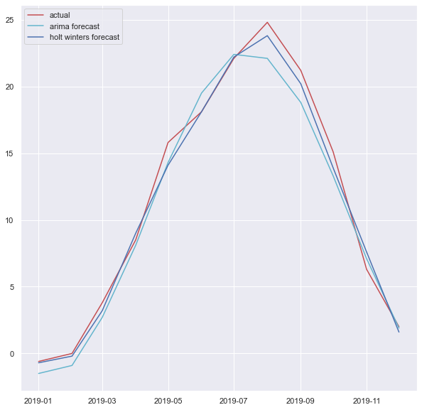

```python
plt.plot(mean_temp_test['mean_temp'], "-r", label="actual")
plt.plot(mean_temp_test['arima forecast'], "-c", label="arima forecast")
plt.plot(mean_temp_test['hw forecast'], "-b", label="holt winters forecast")
plt.legend(loc="upper left")
plt.show()
```

```python
abs(mean_temp_test['mean_temp'] - mean_temp_test['hw forecast'])
```

```
date
2019-01-01    0.1
2019-02-01    0.2
2019-03-01    0.6
2019-04-01    0.5
2019-05-01    1.7
2019-06-01    0.0
2019-07-01    0.1
2019-08-01    1.0
2019-09-01    1.0
2019-10-01    1.2
2019-11-01    1.3
2019-12-01    0.4
dtype: float64
```

```python
round(np.mean(abs(mean_temp_test['mean_temp'] - mean_temp_test['hw forecast'])),2)
```

```
0.67
```

Clearly the ETS model predicts mean monthly temperature more accurately than the ARIMA one. It is worth mentioning that for some months the prediction differs only 0.1 or 0.2 degrees celsius, and for June 2019 the prediction is 100% accurate. The average difference between the actual values and the predicted monthly temperatures is only 0.67 degress celsius. This slight difference might be justified due to the global warming effect on Aomori City of Japan, as the actual temperatures were slghtly higher than the predicted ones, especially during late summer months.